# Laboratorio 2, Estadistica Computacional

## I. Integrantes

- Daniel Aguila (201473106-k)
- Juan Pablo Leon (201473047-0)

## II. Preguntas

### 1.1 Muestreo y Calculo

**Enunciado:** En el juego de cartas Yu-Gi-Oh! una baraja se compone de 3 tipos de cartas: Monstruo, Magia y Trampa. Se cree que una baraja simple esta balanceada o es consistente si la baraja cumple con tener 40 cartas, de las cuales 20 son monstruos, 10 son magias y 10 son trampas. Se define como consistente a aquella baraja en la que la mano inicial posee un numero balanceado de cartas, en este caso, como minimo 1 carta de cada tipo.

**1.1.1** Si en el primer turno el jugador saca 5 cartas de la baraja (sin reemplazo) ¿Cual es la probabilidad de que su mano sea no consistente?

```r
probabilidadNoConsistente <- function (tamanhoMano, repeticiones){
  mazo <- c("MO", "MO", "MO", "MO", "MO", "MO", "MO", "MO", "MO", "MO",
            "MO", "MO", "MO", "MO", "MO", "MO", "MO", "MO", "MO", "MO",
            "MA", "MA", "MA", "MA", "MA", "MA", "MA", "MA", "MA", "MA",
            "T", "T", "T", "T", "T", "T", "T", "T", "T", "T")

  cantidadManosConsistentes <- 0.0

  for(r in 1:repeticiones){
    mazoTemporal <- mazo
    manoTemporal <- c()

    for(i in 1:tamanhoMano){
      indice <- sample(1:length(mazoTemporal), 1)
      manoTemporal <- c(manoTemporal, mazoTemporal[indice])
      mazoTemporal <- mazoTemporal[-indice]

    }

    if( "MO" %in% manoTemporal & "MA" %in% manoTemporal & "T" %in% manoTemporal){
      cantidadManosConsistentes <- cantidadManosConsistentes + 1
    }
  }

  return(1 - cantidadManosConsistentes/repeticiones)
}

probabilidadNoConsistente(5, 10000)
```

```
## [1] 0.4365
```

**1.1.2** Si ahora consideramos que el jugador roba (sacar sin reemplazo) una carta en su primer turno, Â¿Cual es la nueva probabilidad de que la mano no sea consistente?

```r
probabilidadNoConsistente(6, 10000)
```

```
## [1] 0.3104
```

**1.1.3** En el juego, el jugador obtiene una mano inicial de 5 cartas y ademas roba al comienzo de cada turno (incluyendo el primero) 1 carta extra. El jugador cree tener muchos monstruos en su baraja, por lo que cambia 5 de estos por trampas, con la idea de poder defenderse con estas trampas por los primeros 2 turnos hasta obtener un monstruo. ?Cual es la probabilidad de que se cumpla esta estrategia del jugador? esto es, obtener 2 de estas trampas nuevas en la mano original o en los 2 robos consecutivos y luego obtener un monstruo en el tercer robo.

[output not shown]

**1.1.2** Si ahora consideramos que el jugador roba (sacar sin reemplazo) una carta en su primer turno, Â¿Cual es la nueva probabilidad de que la mano no sea consistente?

```r
probabilidadNoConsistente(6, 10000)
```

```
## [1] 0.3121
```

**1.1.3** En el juego, el jugador obtiene una mano inicial de 5 cartas y ademas roba al comienzo de cada turno (incluyendo el primero) 1 carta extra. El jugador cree tener muchos monstruos en su baraja, por lo que cambia 5 de estos por trampas, con la idea de poder defenderse con estas trampas por los primeros 2 turnos hasta obtener un monstruo. ¿Cual es la probabilidad de que se cumpla esta estrategia del jugador? esto es, obtener 2 de estas trampas nuevas en la mano original o en los 2 robos consecutivos y luego obtener un monstruo en el tercer robo.

```r
probabilidadEstrategia <- function (tamanhoMano, repeticiones){
  mazo <- c("TN", "TN", "TN", "TN", "TN", "MO", "MO", "MO", "MO", "MO",
            "MO", "MO", "MO", "MO", "MO", "MO", "MO", "MO", "MO", "MO",
            "MA", "MA", "MA", "MA", "MA", "MA", "MA", "MA", "MA", "MA",
            "T", "T", "T", "T", "T", "T", "T", "T", "T", "T")

  cantidadManosEstrategia <- 0.0

  for(r in 1:repeticiones){
    mazoTemporal <- mazo
    manoTemporal <- c()

    for(i in 1:tamanhoMano){
      indice <- sample(1:length(mazoTemporal), 1)
      manoTemporal <- c(manoTemporal, mazoTemporal[indice])
      mazoTemporal <- mazoTemporal[-indice]

    }

    if("TN" %in% manoTemporal){
      if("TN" %in% manoTemporal[-match("TN", manoTemporal)]){
        if("MO" %in% manoTemporal[tamanhoMano]){
          cantidadManosEstrategia <- cantidadManosEstrategia + 1
        }
      }
    }
  }

  return(cantidadManosEstrategia/repeticiones)
}

probabilidadEstrategia(8, 10000)
```

```
## [1] 0.0796
```

**1.1.4** Si ahora consideramos una baraja mas compleja compuesta por 15 Monstruos debiles, 5 Monstruos fuertes, 5 Magias normales, 5 Magias de equipo, 3 Magias de campo, 5 Trampas normales y 2 Contra-Trampas. ?Cual es la probabilidad de obtener una mano (5 cartas) competitiva? considerar como no competitivo obtener en la primera mano: Monstruos fuertes, Magias de equipo o Trampas normales. Comente la dicultad de realizar este calculo de forma teorica.

[output not shown]

**1.1.4** Si ahora consideramos una baraja mas compleja compuesta por 15 Monstruos debiles, 5 Monstruos fuertes, 5 Magias normales, 5 Magias de equipo, 3 Magias de campo, 5 Trampas normales y 2 Contra-Trampas. ¿Cual es la probabilidad de obtener una mano (5 cartas) competitiva? considerar como no competitivo obtener en la primera mano: Monstruos fuertes, Magias de equipo o Trampas normales. Comente la dicultad de realizar este calculo de forma teorica.

Realizar este calculo de manera teorica no es tan complicado como se esperaria, pues el problema esta asociado a la distribucion hypergeometrica:

$$\begin{equation}
Pr(X=k) = \frac{{K\choose k} {N-K\choose n-k} }{ {N \choose n} }
\end{equation}$$

Donde:

- $N$ es el tamano de la poblacion (40, numero de cartas en el mazo)
- $K$ es el numero de estados exitosos dentro de la poblacion (25, la cantidad de cartas que no causan la no competitividad)
- $n$ es el numero de cartas a robar (5)
- $k$ es el numero de exitos observados en la mano (5, la cantidad de cartas que no causan la no competitivdad que se espera robar)

Un calculo rapido nos entrega que la probabilidad obtener una mano competitiva es cercana a $0.08074$, similar al resultado que obtenemos a continuacion:

```r
probabilidadEstrategiaCompetitiva <- function (tamanhoMano, repeticiones){
  mazo <- c("MOD", "MOD", "MOD", "MOD", "MOD", "MOD", "MOD", "MOD", "MOD", "MOD",
            "MOD", "MOD", "MOD", "MOD", "MOD", "MOF", "MOF", "MOF", "MOF", "MOF",
            "MAN", "MAN", "MAN", "MAN", "MAN", "MAE", "MAE", "MAE", "MAE", "MAE",
            "MAC", "MAC", "MAC", "T", "T", "T", "T", "T", "CT", "CT")

  cantidadManosCompetitivas <- 0.0

  for(r in 1:repeticiones){
    mazoTemporal <- mazo
    manoTemporal <- c()

    for(i in 1:tamanhoMano){
      indice <- sample(1:length(mazoTemporal), 1)
      manoTemporal <- c(manoTemporal, mazoTemporal[indice])
      mazoTemporal <- mazoTemporal[-indice]

    }

    if(!("MOF" %in% manoTemporal)){
      if(!("MAE" %in% manoTemporal)){
        if(!("T" %in% manoTemporal)){
          cantidadManosCompetitivas <- cantidadManosCompetitivas + 1
        }
      }
    }
  }

  return(cantidadManosCompetitivas/repeticiones)
}

probabilidadEstrategiaCompetitiva(5, 10000)
```

```
## [1] 0.0788
```

[output not shown]

### 1.2 Convergencia

**Enunciado:**La teoría nos dice que al tener más datos, las buenas estadísticas sobre los datos suelen ser más precisas y acercase al valor real de los datos. Un ejemplo de esto es el promedio, el cual al tener más datos, converge al valor real de los datos. Considerando la **baraja simple** del ejercicio anterior, sabemos que si obtenemos una carta, las probabilidades de que esta carta sea una magia es de 0,25.

**1.2.1** Muestre como converge la probabilidad de obtener una carta de monstruo al aumentar el tamaño de las muestras con un gráfico. ¿Converge al valor teórico?

```r
#Pregunta 1.2.1
library(ggplot2)

probabilidadRobarMonstruo <- function (repeticiones){
  mazo <- c("MO", "MO", "MO", "MO", "MO", "MO", "MO", "MO", "MO", "MO",
            "MO", "MO", "MO", "MO", "MO", "MO", "MO", "MO", "MO", "MO",
            "MA", "MA", "MA", "MA", "MA", "MA", "MA", "MA", "MA", "MA",
            "T", "T", "T", "T", "T", "T", "T", "T", "T", "T")
  probabilidades <- c()
  cantidadMonstruos <- 0.0

  for(r in 1:repeticiones){
    for(i in 1:r){
      indice <- sample(1:length(mazo), 1)
      if("MO" %in% mazo[indice]){
        cantidadMonstruos <- cantidadMonstruos + 1
      }
    }
    probabilidades <- c(probabilidades, cantidadMonstruos/r)
    cantidadMonstruos <- 0.0
  }
  return(probabilidades)
}

probs <- probabilidadRobarMonstruo(500)
indice <- seq(1, 500, 1)

datos <- data.frame(indice,probs)




# Basic scatter plot
ggplot(datos, aes(x=indice, y=probs)) +
  geom_point() +
  geom_smooth(method=lm, se=FALSE) +
  labs(title="Probabilidad de Robar una Carta de Monstruo",
        x="Cantidad de Pruebas", y = "Probabilidad Obtenida")
```

[figure not shown]

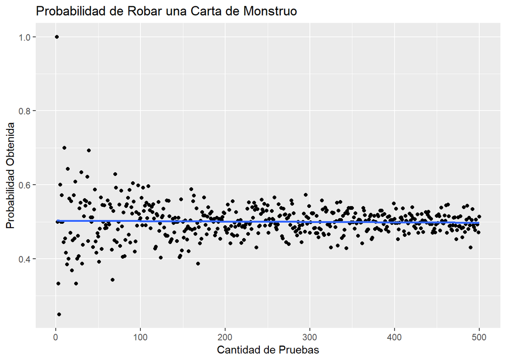

Considerando que la mitad de las cartas en el mazo son del tipo Monstruo, por lo que robar una carta de tal tipo tiene una probabilidad teorica de $0.5$, podemos ver que se el experimento tiende a converger a dicho valor en el gráfico.

**1.2.2** Muestre como converge la probabilidad de obtener una mano inicial (5 cartas) con 5 monstruos. Muestre en el gráfico el valor teórico de esta situación. ¿Es correcta la convergencia mostrada en el gráfico?